# Assignment1: Building Models

Charls Joseph

February 20, 2020

# Multiple Linear Regression

```r
library(MASS)
library(caret)
library(car)
library(corrplot)
library(knitr)
library(mice)
```

## Load the dataset

Load the data set that was curated after the preliminary explanatory analysis.

Plotted a correlation matrix on the original data set

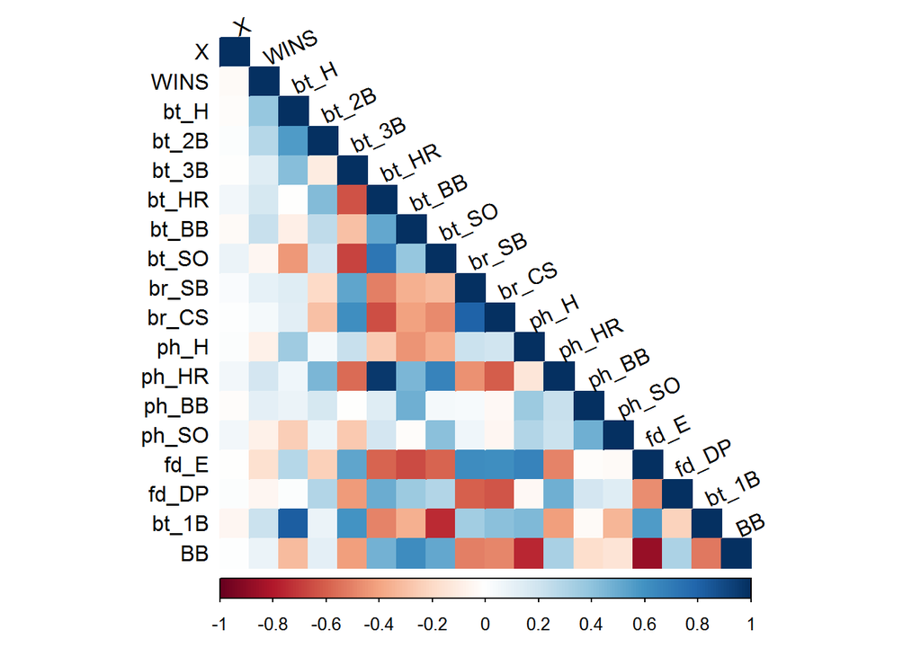

```r
df = read.csv('https://raw.githubusercontent.com/mkivenson/Business-Analytics-Data-Mining/master/Moneyball%20Regression/baseball_output.csv')
corrplot(cor(df, use = "complete.obs"), method="color", type="lower", tl.col = "black", tl.srt = 25)
```

Found that there is a data point with 0 value which needs to be corrected to a non-zero val for BOX-COX transformation later

```r
df[df$WINS == 0,]
```

```
##         X WINS bt_H bt_2B bt_3B bt_HR bt_BB bt_SO br_SB br_CS  ph_H ph_HR ph_BB
## 1211 1211    0  891   135     0     0     0     0     0     0 24057     0     0
##      ph_SO fd_E fd_DP bt_1B BB
## 1211     0 1890   219   756 NA
```

Remove the index column that got added in the preliminary step. Also lift each datapoints by 1 to fix the zero data point.

```r
df <- subset(df, select = -c(X))
df <- df + 1
```

Split the data into training and test data set(80% training and 20% testing)

```r
# Splitting the dataset into the Training set and Test set
# install.packages('caTools')
library(caTools)
set.seed(123)
split = sample.split(df$WINS, SplitRatio = 0.8)
training_set = subset(df, split == TRUE)
test_set = subset(df, split == FALSE)
```

## Assumption of Ordinary Least square regression

Before building and trying out different linear regression models, we will review the assumptions for the OLS algorithm to make it perform well.

1. Residual Error should be normally distributed
2. Absence of hetroschdasticity
3. Absence of Colinearity

We will check these assumption/factors while reviewing the results of each model.

## Full Model

Fitting a full model with all remaining independent variables( “bt_H” “bt_2B” “bt_3B” “bt_HR” “bt_BB” “bt_SO” “br_SB” “br_CS” “ph_H” “ph_HR” “ph_BB” “ph_SO” “fd_E” “fd_DP” “bt_1B” “BB”) and the response variable WINS

```r
colnames(training_set)
```

```
##  [1] "WINS"  "bt_H"  "bt_2B" "bt_3B" "bt_HR" "bt_BB" "bt_SO" "br_SB" "br_CS"
## [10] "ph_H"  "ph_HR" "ph_BB" "ph_SO" "fd_E"  "fd_DP" "bt_1B" "BB"
```

create a dataframe for holding the regression metrics.

```r
regressor_metrics <- data.frame(matrix(ncol = 6, nrow = 0) ,stringsAsFactors = FALSE)
```

```r
# Fitting Multiple Linear Regression to the Training set
fullregressor = lm(formula = WINS ~ . ,
               data = training_set)
```

## Full model Stats

```r
summary(fullregressor)
```

```
##
## Call:
## lm(formula = WINS ~ ., data = training_set)
##
## Residuals:
##     Min      1Q  Median      3Q     Max
## -48.405  -8.181   0.329   7.759  59.627
##
## Coefficients: (1 not defined because of singularities)
##               Estimate Std. Error t value Pr(>|t|)
## (Intercept)  1.115e+02  1.330e+01   8.383  < 2e-16 ***
## bt_H         4.365e-02  4.012e-03  10.882  < 2e-16 ***
## bt_2B       -2.487e-02  9.817e-03  -2.533  0.01139 *
## bt_3B        6.384e-02  1.844e-02   3.461  0.00055 ***
## bt_HR        1.558e-01  3.360e-02   4.638 3.78e-06 ***
## bt_BB        4.178e-02  6.877e-03   6.076 1.50e-09 ***
## bt_SO       -1.176e-02  2.726e-03  -4.316 1.68e-05 ***
## br_SB        4.624e-02  5.487e-03   8.426  < 2e-16 ***
## br_CS        1.364e-02  1.122e-02   1.216  0.22433
## ph_H         1.479e-03  4.608e-04   3.210  0.00135 **
## ph_HR       -7.223e-02  3.069e-02  -2.354  0.01869 *
## ph_BB       -2.114e-02  4.834e-03  -4.373 1.30e-05 ***
## ph_SO        8.737e-04  9.125e-04   0.958  0.33841
## fd_E        -5.399e-02  3.684e-03 -14.655  < 2e-16 ***
## fd_DP       -1.150e-01  1.381e-02  -8.326  < 2e-16 ***
## bt_1B               NA         NA      NA       NA
## BB          -4.238e+01  6.263e+00  -6.766 1.78e-11 ***
## ---
## Signif. codes:  0 '***' 0.001 '**' 0.01 '*' 0.05 '.' 0.1 ' ' 1
##
## Residual standard error: 12.47 on 1809 degrees of freedom
##   (1 observation deleted due to missingness)
## Multiple R-squared:  0.3918, Adjusted R-squared:  0.3868
## F-statistic: 77.69 on 15 and 1809 DF,  p-value: < 2.2e-16
```

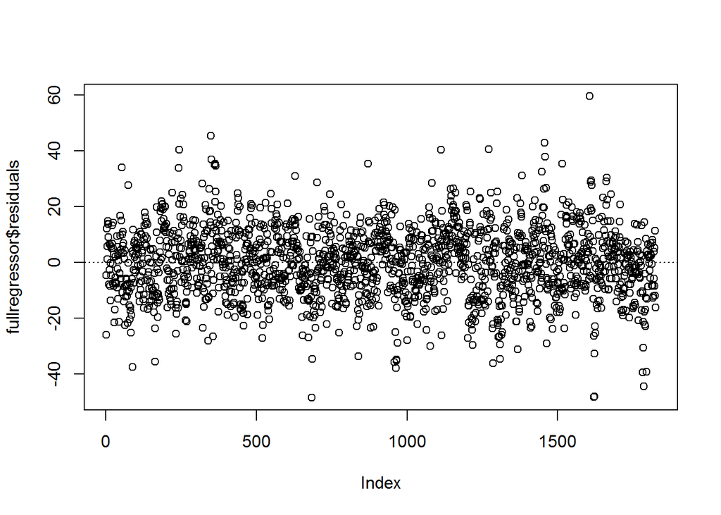

```r
plot(fullregressor$residuals)
abline(h = 0, lty = 3)
```

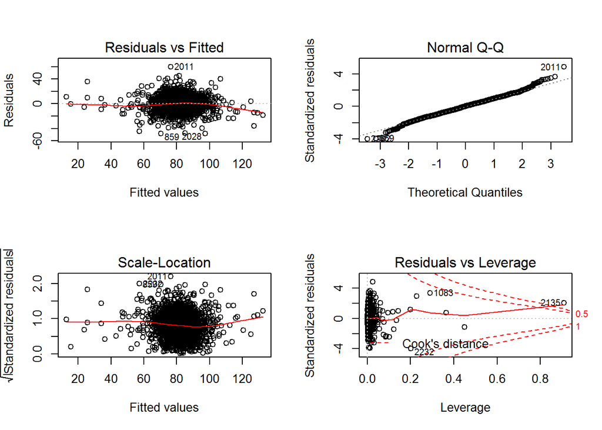

```r
par(mfrow=c(2,2))
plot(fullregressor)
```

## Test evaluation Metrics and prediction results

we see the two independent variables has p-value > 0.05. we will remove this independent variable from the model and try its performance.

since the R-square and RMSE of the model is not that great and it shows a possible underfitting problem. We will try out some transformation like backward elimination, square, logarithmic and BOX-COX transformations and review the results.

```r
predictions = predict(fullregressor, newdata = test_set)
head(data.frame(
  predictions = predictions,
  actual = test_set$WINS
))
```

```
##    predictions actual
## 5     66.72792     83
## 10    66.58775     77
## 21    74.98691     71
## 29    75.99609     82
## 46    87.60120     86
## 48    91.52018     99
```

```r
rmse_test <- round(RMSE(predictions, test_set$WINS), digits=4)
r2_test <- round(R2(predictions, test_set$WINS), digits = 4)
adj_r2_train <- round(summary(fullregressor)$adj.r.squared, digits = 4)
r2_train <- round(summary(fullregressor)$r.squared, digits = 4)
rmse_train <- round(sqrt(mean(fullregressor$residuals^2)), digits = 4)

data.frame(
  rmse_test = rmse_test,
  rmse_train = rmse_train,
  r2_train = r2_train,
  r2_test = r2_test,
  adj_r2_train = adj_r2_train

)
```

```
##   rmse_test rmse_train r2_train r2_test adj_r2_train
## 1   12.8927    12.4108   0.3918   0.241       0.3868
```

```r
regressor_metrics <- rbind(regressor_metrics, c("Full-Model", r2_train , adj_r2_train, rmse_train  , rmse_test , r2_test), stringsAsFactors = FALSE)
```

## Backward Elimination

Through backward elimination process, some independent variables(ph_SO,br_CS, bt_1B) that has pvalue more than the significance level of 0.05 were removed from the full model

```r
regressor_backward_E1 = lm(formula = WINS ~  bt_H+ bt_2B+ bt_3B+ bt_HR+ bt_BB+ bt_SO+ br_SB+ ph_H+ ph_HR+ ph_BB + fd_E+ fd_DP+ BB ,data = training_set)
```

## Backward elimination Model Stats

```r
summary(regressor_backward_E1)
```

```
##
## Call:
## lm(formula = WINS ~ bt_H + bt_2B + bt_3B + bt_HR + bt_BB + bt_SO +
##     br_SB + ph_H + ph_HR + ph_BB + fd_E + fd_DP + BB, data = training_set)
##
## Residuals:
##     Min      1Q  Median      3Q     Max
## -47.845  -8.187   0.450   7.839  60.727
##
## Coefficients:
##               Estimate Std. Error t value Pr(>|t|)
## (Intercept)  1.139e+02  1.319e+01   8.637  < 2e-16 ***
## bt_H         4.346e-02  3.973e-03  10.937  < 2e-16 ***
## bt_2B       -2.517e-02  9.732e-03  -2.587 0.009765 **
## bt_3B        6.687e-02  1.833e-02   3.648 0.000272 ***
## bt_HR        1.623e-01  3.267e-02   4.967 7.42e-07 ***
## bt_BB        3.854e-02  6.228e-03   6.188 7.51e-10 ***
## bt_SO       -1.088e-02  2.511e-03  -4.335 1.54e-05 ***
## br_SB        5.046e-02  4.592e-03  10.990  < 2e-16 ***
## ph_H         1.441e-03  4.589e-04   3.139 0.001722 **
## ph_HR       -8.049e-02  2.969e-02  -2.711 0.006778 **
## ph_BB       -1.847e-02  4.188e-03  -4.411 1.09e-05 ***
## fd_E        -5.440e-02  3.631e-03 -14.982  < 2e-16 ***
## fd_DP       -1.171e-01  1.344e-02  -8.710  < 2e-16 ***
## BB          -4.282e+01  6.236e+00  -6.866 9.05e-12 ***
## ---
## Signif. codes:  0 '***' 0.001 '**' 0.01 '*' 0.05 '.' 0.1 ' ' 1
##
## Residual standard error: 12.47 on 1811 degrees of freedom
##   (1 observation deleted due to missingness)
## Multiple R-squared:  0.391,  Adjusted R-squared:  0.3866
## F-statistic: 89.42 on 13 and 1811 DF,  p-value: < 2.2e-16
```

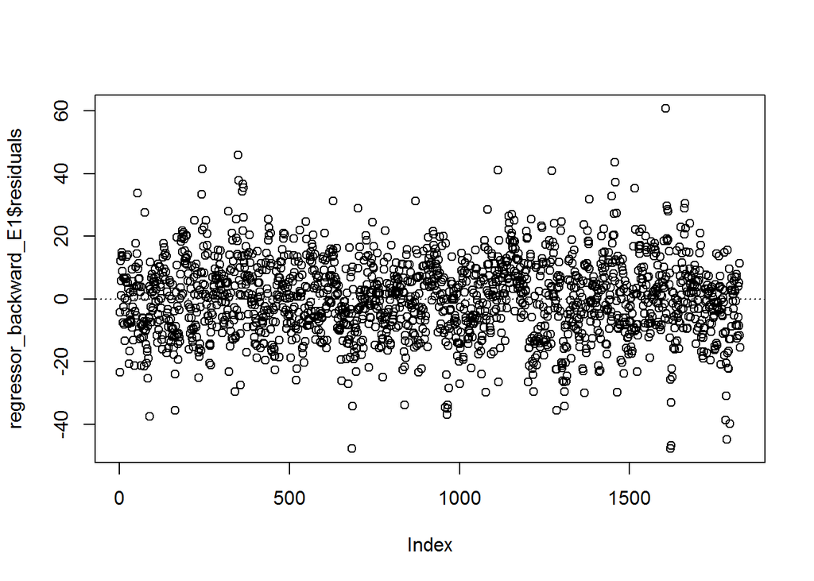

```r
plot(regressor_backward_E1$residuals)
abline(h = 0, lty = 3)
```

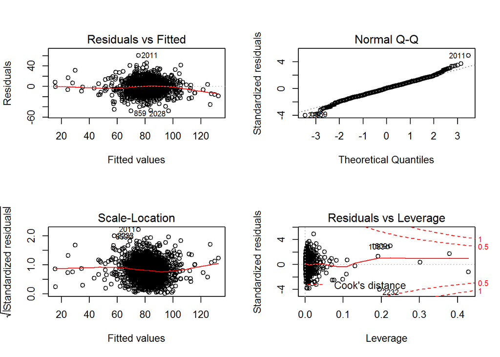

```r
par(mfrow=c(2,2))
plot(regressor_backward_E1)
```

## Test evaluation Metrics and prediction results

```r
predictions = predict(regressor_backward_E1, newdata = test_set)
head(data.frame(
  predictions = predictions,
  actual = test_set$WINS
))
```

```
##    predictions actual
## 5     66.80905     83
## 10    66.85463     77
## 21    74.79397     71
## 29    76.03111     82
## 46    87.70131     86
## 48    91.57863     99
```

```r
rmse_test <- round(RMSE(predictions, test_set$WINS), digits=4)
r2_test <- round(R2(predictions, test_set$WINS), digits = 4)
adj_r2_train <- round(summary(regressor_backward_E1)$adj.r.squared, digits = 4)
r2_train <- round(summary(regressor_backward_E1)$r.squared, digits = 4)
rmse_train <- round(sqrt(mean(regressor_backward_E1$residuals^2)), digits = 4)

data.frame(
  rmse_test = rmse_test,
  rmse_train = rmse_train,
  r2_train = r2_train,
  r2_test = r2_test,
  adj_r2_train = adj_r2_train

)
```

```
##   rmse_test rmse_train r2_train r2_test adj_r2_train
## 1   12.9301    12.4195    0.391  0.2381       0.3866
```

```r
regressor_metrics <- rbind(regressor_metrics, c("Backward elimination-1", r2_train , adj_r2_train, rmse_train  , rmse_test , r2_test), stringsAsFactors = FALSE)
```

## Backward Elimination + removal of colinear Variables

Performing a VIF Test on all variables to remove some independent variables which are colinear( VIF has more than 5)

```r
model1 <- lm(WINS ~ bt_H+ bt_2B+ bt_3B+ bt_HR+ bt_BB+ bt_SO+ br_SB+ ph_H+ ph_HR+ ph_BB + fd_E+ fd_DP+ BB, data = df)
car::vif(model1)
```

```
##      bt_H     bt_2B     bt_3B     bt_HR     bt_BB     bt_SO     br_SB      ph_H
##  4.014112  2.464797  3.033585 46.653155  5.981965  4.528813  2.695233  4.896792
##     ph_HR     ph_BB      fd_E     fd_DP        BB
## 39.716223  4.674980  8.358823  1.898830 10.757738
```

```r
regressor_backward_E2 = lm(formula = WINS ~  bt_H+ bt_2B + br_SB + ph_BB + fd_E+ fd_DP  ,data = training_set)
```

## Backward elimination Model Stats( with removal of colinear variables)

```r
summary(regressor_backward_E2)
```

```
##
## Call:
## lm(formula = WINS ~ bt_H + bt_2B + br_SB + ph_BB + fd_E + fd_DP,
##     data = training_set)
##
## Residuals:
##     Min      1Q  Median      3Q     Max
## -53.579  -8.577   0.122   8.482  49.278
##
## Coefficients:
##              Estimate Std. Error t value Pr(>|t|)
## (Intercept) 12.207764   3.593651   3.397 0.000696 ***
## bt_H         0.059449   0.002877  20.662  < 2e-16 ***
## bt_2B       -0.021329   0.009053  -2.356 0.018579 *
## br_SB        0.040128   0.004117   9.747  < 2e-16 ***
## ph_BB        0.006392   0.001998   3.200 0.001399 **
## fd_E        -0.038440   0.001792 -21.450  < 2e-16 ***
## fd_DP       -0.084982   0.013246  -6.416 1.78e-10 ***
## ---
## Signif. codes:  0 '***' 0.001 '**' 0.01 '*' 0.05 '.' 0.1 ' ' 1
##
## Residual standard error: 12.93 on 1819 degrees of freedom
## Multiple R-squared:  0.3511, Adjusted R-squared:  0.349
## F-statistic: 164.1 on 6 and 1819 DF,  p-value: < 2.2e-16
```

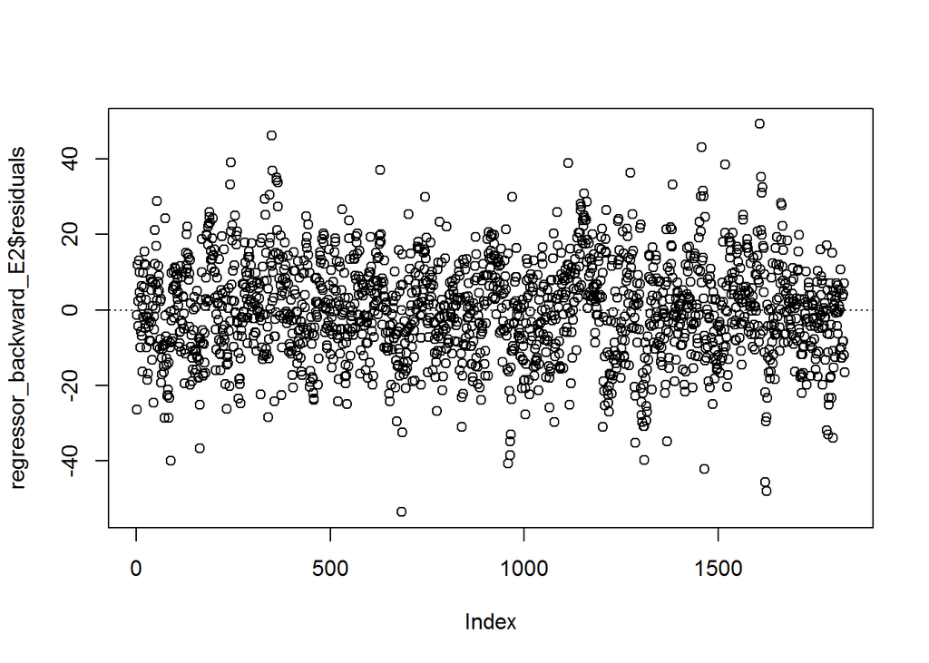

```r
plot(regressor_backward_E2$residuals)
abline(h = 0, lty = 3)
```

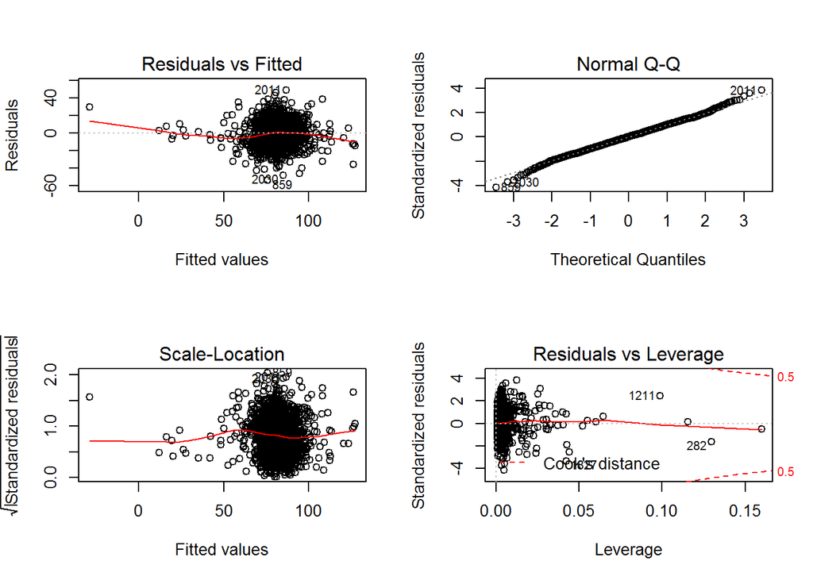

```r
par(mfrow=c(2,2))
plot(regressor_backward_E2)
```

```r
predictions = predict(regressor_backward_E2, newdata = test_set)
head(data.frame(
  predictions = predictions,
  actual = test_set$WINS
))
```

```
##    predictions actual
## 5     70.70862     83
## 10    70.34577     77
## 21    77.07268     71
## 29    79.39163     82
## 46    84.77783     86
## 48    88.10494     99
```

```r
rmse_test <- round(RMSE(predictions, test_set$WINS), digits=4)
r2_test <- round(R2(predictions, test_set$WINS), digits = 4)
adj_r2_train <- round(summary(regressor_backward_E2)$adj.r.squared, digits = 4)
r2_train <- round(summary(regressor_backward_E2)$r.squared, digits = 4)
rmse_train <- round(sqrt(mean(regressor_backward_E2$residuals^2)), digits = 4)

data.frame(
  rmse_test = rmse_test,
  rmse_train = rmse_train,
  r2_train = r2_train,
  r2_test = r2_test,
  adj_r2_train = adj_r2_train

)
```

```
##   rmse_test rmse_train r2_train r2_test adj_r2_train
## 1   12.7212    12.9056   0.3511  0.2413        0.349
```

```r
regressor_metrics <- rbind(regressor_metrics, c("Backward elimination-2", r2_train , adj_r2_train, rmse_train  , rmse_test , r2_test), stringsAsFactors = FALSE)
```

## Square transformation Model

```r
# Fitting Multiple Linear Regression to the Training set
#"bt_H"  "bt_2B" "bt_3B" "br_SB" "br_CS" "ph_H"  "fd_E"  "fd_DP"
regressor_sq = lm(WINS ~ I(bt_H^2)+ I(bt_2B^2) + (br_SB^2) + (ph_BB^2) + (fd_E^2)+ (fd_DP^2) ,
               data = training_set)
```

## Square transformation Model Stats

```r
summary(regressor_sq)
```

```
##
## Call:
## lm(formula = WINS ~ I(bt_H^2) + I(bt_2B^2) + (br_SB^2) + (ph_BB^2) +
##     (fd_E^2) + (fd_DP^2), data = training_set)
##
## Residuals:
##     Min      1Q  Median      3Q     Max
## -52.831  -8.729   0.132   8.529  49.738
##
## Coefficients:
##               Estimate Std. Error t value Pr(>|t|)
## (Intercept)  5.641e+01  2.486e+00  22.694  < 2e-16 ***
## I(bt_H^2)    1.858e-05  8.849e-07  21.002  < 2e-16 ***
## I(bt_2B^2)  -3.519e-05  1.734e-05  -2.029  0.04256 *
## br_SB        4.152e-02  4.116e-03  10.088  < 2e-16 ***
## ph_BB        5.967e-03  1.998e-03   2.987  0.00286 **
## fd_E        -3.987e-02  1.795e-03 -22.219  < 2e-16 ***
## fd_DP       -8.490e-02  1.322e-02  -6.424 1.69e-10 ***
## ---
## Signif. codes:  0 '***' 0.001 '**' 0.01 '*' 0.05 '.' 0.1 ' ' 1
##
## Residual standard error: 12.93 on 1819 degrees of freedom
## Multiple R-squared:  0.3508, Adjusted R-squared:  0.3487
## F-statistic: 163.8 on 6 and 1819 DF,  p-value: < 2.2e-16
```

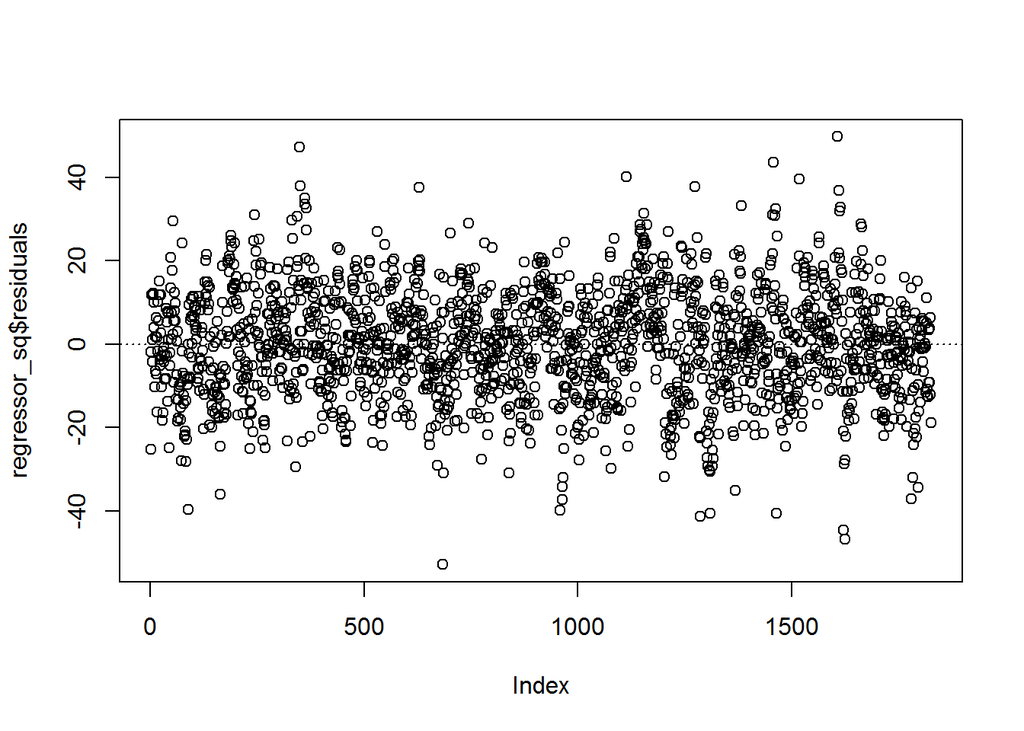

```r
plot(regressor_sq$residuals)
abline(h = 0, lty = 3)
```

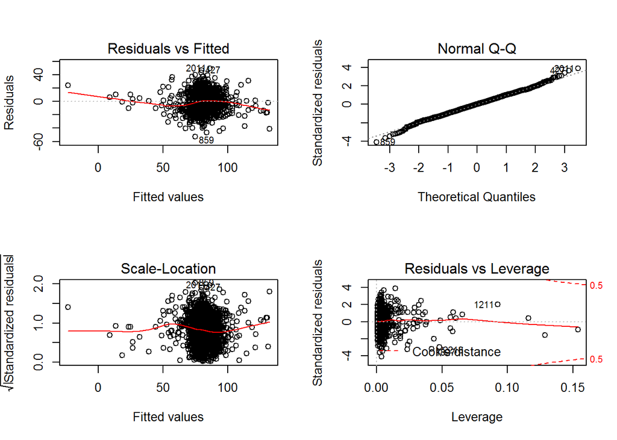

```r
par(mfrow=c(2,2))
plot(regressor_sq)
```

## Test evaluation Metrics and prediction results

RMSE(test) has improved, but R-square is reduced slightly.

```r
predictions = predict(regressor_sq, newdata = test_set)
head(data.frame(
  predictions = predictions,
  actual = test_set$WINS
))
```

```
##    predictions actual
## 5     71.49189     83
## 10    71.68233     77
## 21    76.78273     71
## 29    79.73048     82
## 46    84.73991     86
## 48    88.01546     99
```

```r
rmse_test <- round(RMSE(predictions, test_set$WINS), digits=4)
r2_test <- round(R2(predictions, test_set$WINS), digits = 4)
adj_r2_train <- round(summary(regressor_sq)$adj.r.squared, digits = 4)
r2_train <- round(summary(regressor_sq)$r.squared, digits = 4)
rmse_train <- round(sqrt(mean(regressor_sq$residuals^2)), digits = 4)

data.frame(
  rmse_test = rmse_test,
  rmse_train = rmse_train,
  r2_train = r2_train,
  r2_test = r2_test,
  adj_r2_train = adj_r2_train

)
```

```
##   rmse_test rmse_train r2_train r2_test adj_r2_train
## 1   12.6774    12.9088   0.3508  0.2459       0.3487
```

```r
regressor_metrics <- rbind(regressor_metrics, c("Square Transformation", r2_train , adj_r2_train, rmse_train  , rmse_test , r2_test), stringsAsFactors = FALSE)
```

## Logarithmic transformation

```r
# Fitting Multiple Linear Regresion to the Training set
regressor_log = lm(WINS ~  log1p(bt_H)+ log1p(bt_2B) + log1p(br_SB) + log1p(ph_BB) + log1p(fd_E)+ log1p(fd_DP),
               data = training_set)
```

## Logarithmic transformation Stats

```r
summary(regressor_log)
```

```
##
## Call:
## lm(formula = WINS ~ log1p(bt_H) + log1p(bt_2B) + log1p(br_SB) +
##     log1p(ph_BB) + log1p(fd_E) + log1p(fd_DP), data = training_set)
##
## Residuals:
##     Min      1Q  Median      3Q     Max
## -54.379  -8.525  -0.049   8.348  50.265
##
## Coefficients:
##               Estimate Std. Error t value Pr(>|t|)
## (Intercept)  -453.2839    26.5293 -17.086  < 2e-16 ***
## log1p(bt_H)    97.0853     4.7161  20.586  < 2e-16 ***
## log1p(bt_2B)   -9.6544     2.3418  -4.123 3.91e-05 ***
## log1p(br_SB)    4.8338     0.5874   8.229 3.56e-16 ***
## log1p(ph_BB)    3.5732     1.1583   3.085  0.00207 **
## log1p(fd_E)   -14.5104     0.7717 -18.804  < 2e-16 ***
## log1p(fd_DP)  -17.8524     1.8683  -9.555  < 2e-16 ***
## ---
## Signif. codes:  0 '***' 0.001 '**' 0.01 '*' 0.05 '.' 0.1 ' ' 1
##
## Residual standard error: 13.02 on 1819 degrees of freedom
## Multiple R-squared:  0.3419, Adjusted R-squared:  0.3397
## F-statistic: 157.5 on 6 and 1819 DF,  p-value: < 2.2e-16
```

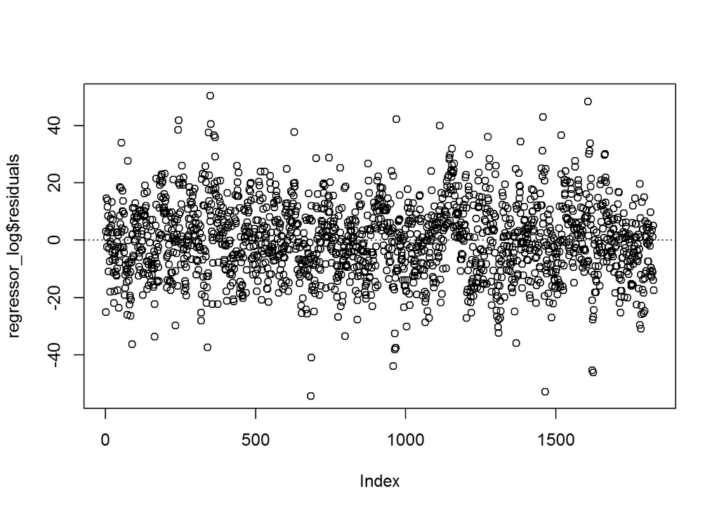

```r
plot(regressor_log$residuals)
abline(h = 0, lty = 3)
```

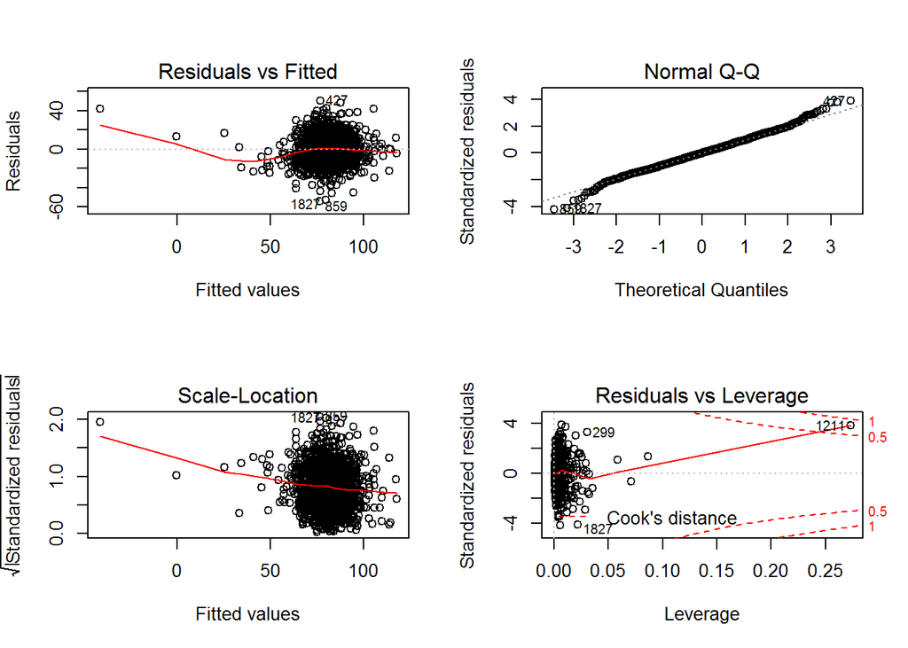

```r
par(mfrow=c(2,2))
plot(regressor_log)
```

## Test evaluation Metrics and prediction results

Residual Error plot developed a slight cure and OLS assumptions are not met.

```r
predictions = predict(regressor_log, newdata = test_set)
head(data.frame(
  predictions = predictions,
  actual = test_set$WINS
))
```

```
##    predictions actual
## 5     69.82943     83
## 10    69.84392     77
## 21    74.99316     71
## 29    82.81690     82
## 46    88.47094     86
## 48    94.84237     99
```

```r
rmse_test <- round(RMSE(predictions, test_set$WINS), digits=4)
r2_test <- round(R2(predictions, test_set$WINS), digits = 4)
adj_r2_train <- round(summary(regressor_log)$adj.r.squared, digits = 4)
r2_train <- round(summary(regressor_log)$r.squared, digits = 4)
rmse_train <- round(sqrt(mean(regressor_log$residuals^2)), digits = 4)

data.frame(
  rmse_test = rmse_test,
  rmse_train = rmse_train,
  r2_train = r2_train,
  r2_test = r2_test,
  adj_r2_train = adj_r2_train

)
```

```
##   rmse_test rmse_train r2_train r2_test adj_r2_train
## 1   13.0509    12.9974   0.3419  0.2117       0.3397
```

```r
regressor_metrics <- rbind(regressor_metrics, c("Log Transformation", r2_train , adj_r2_train, rmse_train  , rmse_test , r2_test), stringsAsFactors = FALSE)
```

## box cox transformation

Trying out a box-cox transformation. Used the best model so far which is backward elimination model to apply BOX-COX transformation. Lambda comes close to 1. So it doesnt make any difference and there is no need to apply the BOX-COX tranformation.

```r
bc = boxcox(regressor_backward_E2)
```

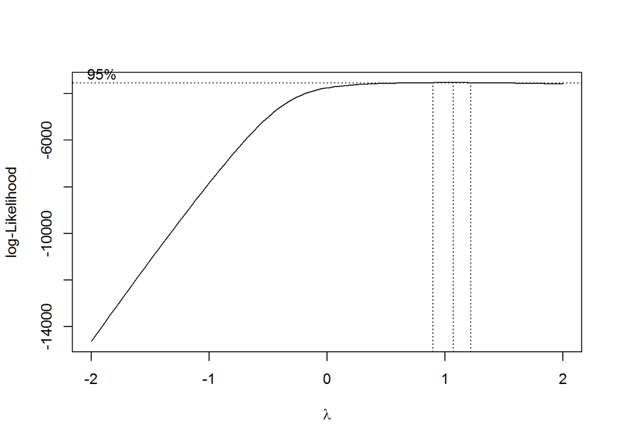

## Cross validation

Performing a cross validation algorithm if it make some improvement.

```r
library(caret)
set.seed(123)

regression_cv <- train(
  WINS ~ bt_H+ bt_2B + br_SB + ph_BB + fd_E+ fd_DP , training_set,
  method = "lm",
  trControl = trainControl(
    method = "cv",
    number =10,
    verboseIter = TRUE
  )
)
```

```r
summary(regression_cv)
```

```
##
## Call:
## lm(formula = .outcome ~ ., data = dat)
##
## Residuals:
##     Min      1Q  Median      3Q     Max
## -53.579  -8.577   0.122   8.482  49.278
##
## Coefficients:
##              Estimate Std. Error t value Pr(>|t|)
## (Intercept) 12.207764   3.593651   3.397 0.000696 ***
## bt_H         0.059449   0.002877  20.662  < 2e-16 ***
## bt_2B       -0.021329   0.009053  -2.356 0.018579 *
## br_SB        0.040128   0.004117   9.747  < 2e-16 ***
## ph_BB        0.006392   0.001998   3.200 0.001399 **
## fd_E        -0.038440   0.001792 -21.450  < 2e-16 ***
## fd_DP       -0.084982   0.013246  -6.416 1.78e-10 ***
## ---
## Signif. codes:  0 '***' 0.001 '**' 0.01 '*' 0.05 '.' 0.1 ' ' 1
##
## Residual standard error: 12.93 on 1819 degrees of freedom
## Multiple R-squared:  0.3511, Adjusted R-squared:  0.349
## F-statistic: 164.1 on 6 and 1819 DF,  p-value: < 2.2e-16
```

```r
predictions = predict(regression_cv, newdata = test_set)
head(data.frame(
  predictions = predictions,
  actual = test_set$WINS
))
```

```
##    predictions actual
## 5     70.70862     83
## 10    70.34577     77
## 21    77.07268     71
## 29    79.39163     82
## 46    84.77783     86
## 48    88.10494     99
```

```r
rmse_test <- round(RMSE(predictions, test_set$WINS), digits=4)
r2_test <- round(R2(predictions, test_set$WINS), digits = 4)
adj_r2_train <- round(summary(regression_cv)$adj.r.squared, digits = 4)
r2_train <- round(summary(regression_cv)$r.squared, digits = 4)
rmse_train <- round(sqrt(mean(regression_cv$residuals^2)), digits = 4)

data.frame(
  rmse_test = rmse_test,
  rmse_train = rmse_train,
  r2_train = r2_train,
  r2_test = r2_test,
  adj_r2_train = adj_r2_train

)
```

```
##   rmse_test rmse_train r2_train r2_test adj_r2_train
## 1   12.7212        NaN   0.3511  0.2413        0.349
```

```r
regressor_metrics <- rbind(regressor_metrics, c("Cross Validation", r2_train , adj_r2_train, rmse_train  , rmse_test , r2_test), stringsAsFactors = FALSE)

metrics <- c("regressor", "Rsquare(Train-set)", "Adjusted-RSquare(Training-set)","RMSE(Train-set)" ,  "RMSE(Test-set)", "R-Square(Test)")
colnames(regressor_metrics) <- metrics
kable(regressor_metrics)
```

| regressor | Rsquare(Train-set) | Adjusted-RSquare(Training-set) | RMSE(Train-set) | RMSE(Test-set) | R-Square(Test) |
| --- | --- | --- | --- | --- | --- |
| Full-Model | 0.3918 | 0.3868 | 12.4108 | 12.8927 | 0.241 |
| Backward elimination-1 | 0.391 | 0.3866 | 12.4195 | 12.9301 | 0.2381 |
| Backward elimination-2 | 0.3511 | 0.349 | 12.9056 | 12.7212 | 0.2413 |
| Square Transformation | 0.3508 | 0.3487 | 12.9088 | 12.6774 | 0.2459 |
| Log Transformation | 0.3419 | 0.3397 | 12.9974 | 13.0509 | 0.2117 |
| Cross Validation | 0.3511 | 0.349 | NaN | 12.7212 | 0.2413 |

## Summary of findings

1. Model built using Backward Elimination-2 and Square transformation looks to be the best among all models considering comparetively low RMSE(test) and comparetively good R-square values.
2. Less R^2 and high RMSE shows an underfitting problem. The dataset doesnt follow a linear relationship with the response variable.
3. Although the model exhibits an underfitting problem, it slightly met the ordinary least square assumptions.
1. Residuals doesnt have high variance.
2. Residual QQ plots gives a slight straight line.
4. Residual Error plot shows a slight cure and OLS assumptions are not met.
5. Metrics shows RMSE(Train) and RMSE(TEST) is almost same and dont have much differences. But the R^2 has some difference for all the models. We will see some overfitting solution and check the model gets improved further in next step.

## Ridge Regression

Lets try out the ridge regression with cross validation.

```r
library(glmnet)
lambda <- 10^seq(-3, 3, length = 100)

# Build the model
set.seed(123)
ridge <- train(
  WINS ~ bt_H+ bt_2B + br_SB + ph_BB + fd_E+ fd_DP , data = training_set, method = "glmnet",
  trControl = trainControl("cv", number = 10),
  tuneGrid = expand.grid(alpha = 0, lambda = lambda)
  )
# Model coefficients
coef(ridge$finalModel, ridge$bestTune$lambda)
```

```
## 7 x 1 sparse Matrix of class "dgCMatrix"
##                        1
## (Intercept) 16.789041438
## bt_H         0.053359100
## bt_2B       -0.007399118
## br_SB        0.035809230
## ph_BB        0.006233650
## fd_E        -0.034062969
## fd_DP       -0.080906289
```

R^2(test) and RMSE doesn’t get improved

```r
# Make predictions
predictions <- predict(ridge, test_set)
# Model prediction performance
head(data.frame(
  predictions = predictions,
  actual = test_set$WINS
))
```

```
##    predictions actual
## 5     70.99658     83
## 10    71.00643     77
## 21    77.27990     71
## 29    79.50153     82
## 46    84.89866     86
## 48    88.04531     99
```

```r
data.frame(
  RMSE = RMSE(predictions, test_set$WINS),
  Rsquare = R2(predictions, test_set$WINS)
)
```

```
##       RMSE   Rsquare
## 1 12.71836 0.2403934
```

# lassso

Lets try out the Lasso regression with cross validation.

```r
# Build the model
set.seed(123)
lasso <- train(
  WINS ~ bt_H+ bt_2B + br_SB + ph_BB + fd_E+ fd_DP , data = training_set, method = "glmnet",
  trControl = trainControl("cv", number = 10),
  tuneGrid = expand.grid(alpha = 1, lambda = lambda)
  )
# Model coefficients
coef(lasso$finalModel, lasso$bestTune$lambda)
```

```
## 7 x 1 sparse Matrix of class "dgCMatrix"
##                        1
## (Intercept) 12.536563485
## bt_H         0.058912750
## bt_2B       -0.019708708
## br_SB        0.039811044
## ph_BB        0.006247125
## fd_E        -0.038077537
## fd_DP       -0.084283559
```

R^2 and RMSE doesn’t get improved

```r
# Make predictions
predictions <-  predict(lasso, test_set)
# Model prediction performance
data.frame(
  RMSE = RMSE(predictions, test_set$WINS),
  Rsquare = R2(predictions, test_set$WINS)
)
```

```
##       RMSE   Rsquare
## 1 12.72148 0.2410859
```

# Elastic net

Lets try out the Elastic net regression with cross validation.

```r
# Build the model
set.seed(123)
elastic <- train(
  WINS  ~bt_H+ bt_2B + br_SB + ph_BB + fd_E+ fd_DP , data = training_set, method = "glmnet",
  trControl = trainControl("cv", number = 10),
  tuneLength = 10
  )
# Model coefficients
coef(elastic$finalModel, elastic$bestTune$lambda)
```

```
## 7 x 1 sparse Matrix of class "dgCMatrix"
##                        1
## (Intercept) 12.567573359
## bt_H         0.058888868
## bt_2B       -0.019710177
## br_SB        0.039783371
## ph_BB        0.006269394
## fd_E        -0.038058422
## fd_DP       -0.084345388
```

R^2 and RMSE doesn’t get improved

```r
# Make predictions
predictions <- predict(elastic, test_set)
# Model prediction performance
head(data.frame(
  predictions = predictions,
  actual = test_set$WINS
))
```

```
##    predictions actual
## 5     70.72962     83
## 10    70.41252     77
## 21    77.10584     71
## 29    79.41875     82
## 46    84.80441     86
## 48    88.09797     99
```

```r
data.frame(
  RMSE = RMSE(predictions, test_set$WINS),
  Rsquare = R2(predictions, test_set$WINS)
)
```

```
##       RMSE   Rsquare
## 1 12.72105 0.2411239
```

overfitting Solution didnt take any effect, so there is no improvement to the best model we identified above.

## Prediction of evaluation data set

```r
trimColumn <- function(df) {
  names(df) <- sub("TEAM_", "", names(df))
names(df) <- sub("BATTING_", "bt_", names(df))
names(df) <- sub("BASERUN_", "br_", names(df))
names(df) <- sub("FIELDING_", "fd_", names(df))
names(df) <- sub("PITCHING_", "ph_", names(df))
names(df) <- sub("TARGET_", "", names(df))
head(df)
df
}

LoadandpreprocessEvaluationSet <- function () {
  # load training set
  df_train <- read.csv("https://raw.githubusercontent.com/mkivenson/Business-Analytics-Data-Mining/master/Moneyball%20Regression/moneyball-training-data.csv")[-1]
  # trim the column name and drop the response variable from training set
  df_train <- trimColumn(df_train)
  #drop the response variable from training set. we have to combine it with the evaluation data set and needs have same columns.

  df_train <- subset(df_train , select = -c(WINS))

  #create a new column to indidcate it is training set or evaluation set
  df_train$type = 0
  # seprate out the evaluation set and return
  df_eval <- read.csv("https://raw.githubusercontent.com/mkivenson/Business-Analytics-Data-Mining/master/Moneyball%20Regression/moneyball-evaluation-data.csv")[-1]
  #trim the evaluation columns
  df_eval <- trimColumn(df_eval)

  #create a new column to indidcate it is training set or evaluation set, Set to 1
  df_eval$type =1
  # combine training and evaluation in one df and apply the required tranformation for missing data
  df_full <- rbind(df_train, df_eval)
  df_full$bt_1B <- df_full$bt_H - df_full$bt_2B - df_full$bt_3B - df_full$bt_HR
  df_full$BB <- df_full$bt_BB / df_full$ph_BB

  # transform the missing data using impute function
  df_full <- imputeMissingData(df_full)
  #filter only the evaluation set
  df_eval <- df_full[df_full$type == 1, ]
  #return the evaluation set
  df_eval
}
```

```r
df_eval <- LoadandpreprocessEvaluationSet()
df_eval<- subset(df_eval , select = -c(type))
#lift the data points by 1 to fix the zero data points( did the same transformation for training set while building the model)

df_eval<-df_eval + 1
eval_data <- read.csv("https://raw.githubusercontent.com/mkivenson/Business-Analytics-Data-Mining/master/Moneyball%20Regression/moneyball-evaluation-data.csv")
```

## Evaluating using Square transformation model

```r
predictions = predict(regressor_sq, newdata = df_eval)
eval_data$WINS <- ceiling(predictions- 1)
kable(eval_data[, c("INDEX", "WINS")])
```

| INDEX | WINS |
| --- | --- |
| 9 | 68 |
| 10 | 69 |
| 14 | 77 |
| 47 | 88 |
| 60 | 65 |
| 63 | 69 |
| 74 | 83 |
| 83 | 79 |
| 98 | 73 |
| 120 | 76 |
| 123 | 74 |
| 135 | 79 |
| 138 | 76 |
| 140 | 79 |
| 151 | 83 |
| 153 | 77 |
| 171 | 75 |
| 184 | 79 |
| 193 | 74 |
| 213 | 90 |
| 217 | 83 |
| 226 | 86 |
| 230 | 79 |
| 241 | 72 |
| 291 | 84 |
| 294 | 88 |
| 300 | 48 |
| 348 | 77 |
| 350 | 85 |
| 357 | 80 |

[output cut: 229 more lines]

## Evaluating using Backward elimination model

```r
predictions = predict(regressor_backward_E2, newdata = df_eval)
eval_data$WINS <- ceiling(predictions- 1)
kable(eval_data[, c("INDEX", "WINS")])
```

| INDEX | WINS |
| --- | --- |
| 9 | 67 |
| 10 | 67 |
| 14 | 77 |
| 47 | 88 |
| 60 | 66 |
| 63 | 69 |
| 74 | 83 |
| 83 | 79 |
| 98 | 72 |
| 120 | 76 |
| 123 | 74 |
| 135 | 80 |
| 138 | 77 |
| 140 | 80 |
| 151 | 83 |
| 153 | 77 |
| 171 | 74 |
| 184 | 79 |
| 193 | 74 |
| 213 | 90 |
| 217 | 83 |
| 226 | 86 |
| 230 | 79 |
| 241 | 72 |
| 291 | 84 |
| 294 | 89 |
| 300 | 51 |
| 348 | 77 |
| 350 | 86 |
| 357 | 80 |

[output cut: 229 more lines]